[figure not shown]

# A propos du moustique Tigre

[figure not shown]

Vous trouverez ici les ressources nécéssaires pour mener à bien le projet “Moustique Tigre” lors de la semaine des [Mouettes Savantes 2026](https://marieetienne.github.io/lesmouettessavantes/).

### 0. Contexte

Vous avez toutes entendu parler du moustique tigre. A l’aide d’outils numériques et mathématique, nous allons nous pencher sur cette invasion, ses conséquences et les solutions envisageable.

### 1. Le moustique est-il dangereux?

A l’aide de recherches sur internet et d’analyse de données, on se demandera pourquoi on craint tant le moustique tigre.

**Données à disposition**:

- Cas de dengue, zika et chikungunya (données issues de santé public france).
- Présence du moustique sur le territoire métropolitain par département
- Progression du moustique sur le territoire métropolitain au cours du temps

### 2. Peut-on éradiquer le moustique?

Dans cet [article](https://www.inserm.fr/actualite/des-moustiques-genetiquement-modifies-pour-lutter-contre-la-propagation-des-maladies/), l’inserm propose des solutions pour contenir l’invasion. Nous allons utiliser un modèle mathématique et du code python pour comprendre comment évolue une population de moustiques tigre.

- Ecrire un programme Python permettant de “modéliser” une population de moustique tigre. On se basera sur le cycle de vie du moustique tigre simplifié:

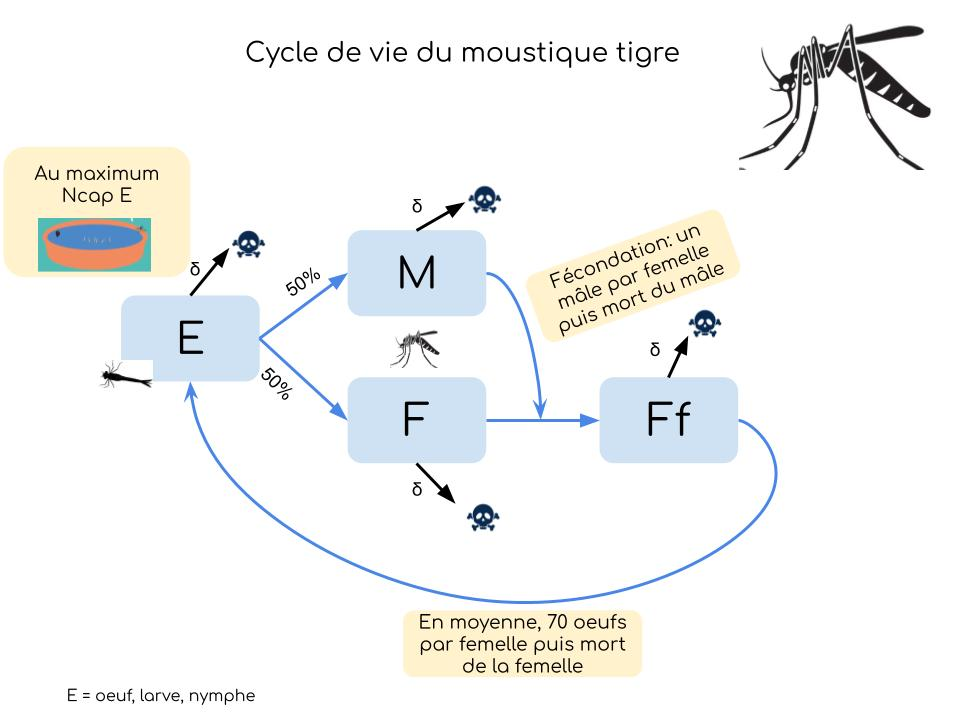

- Modifier ce cycle de vie en fonction des 2 techniques proposées par l’INSERM
- Ecrire les programmes permettant de comparer l’évolution dans ces situations
- Peut-on évaluer les couts financiers de chaque technique pour une même efficacité?

*Last update on 08/06/26*